# Formative Assignment: Summarising Multivariate Data and PCA

240609924

### 1. Introduction

This report analyses the airpollution dataset, which contains measurements from 80 US cities in 1960 across 11 variables, including air pollution concentrations and demographic indicators. The objective of this analysis is to provide numerical and graphical summaries of the data, compute key statistical measures such as total variation and generalised variance, and explore the underlying structure of the dataset using Principal Component Analysis (PCA). By systematically evaluating the data, the report aims to highlight key patterns and relationships among variables, assess the suitability of standardisation for PCA, and identify the most influential principal components that encapsulate the dataset’s variability. These insights provide a foundation for interpreting environmental and demographic trends while demonstrating effective application of multivariate techniques.

### 2. Exploratory Data Analysis (EDA)

In this part, we aim to understand the structure of the airpollution dataset by generating numerical summaries and visualising the relationships among variables. We will calculate key statistics such as means, standard deviations, and ranges for each variable and assess their distributions using histograms and scatterplot matrices. These steps help uncover patterns, identify anomalies, and provide insights into the variability and relationships between the variables.

#### 2.1 Numerical Summaries

Table 1: Summary Statistics for All Air Pollution Variables

|  | Mean | SD | Min | Max |
| --- | --- | --- | --- | --- |
| SMIN | 47.10000 | 30.218445 | 1.0000 | 155.0000 |
| SMEAN | 99.65000 | 50.427564 | 26.0000 | 283.0000 |
| SMAX | 219.87500 | 120.038957 | 58.0000 | 940.0000 |
| PMIN | 44.50000 | 18.380645 | 10.0000 | 98.0000 |
| PMEAN | 116.72500 | 38.837531 | 54.0000 | 247.0000 |
| PMAX | 275.53750 | 159.099041 | 117.0000 | 978.0000 |
| PM2 | 72.85875 | 154.661688 | 1.6000 | 1357.2000 |
| PERWH | 87.25750 | 10.383687 | 60.0000 | 99.7000 |
| NONPOOR | 81.82875 | 6.741862 | 67.8000 | 93.2000 |
| GE65 | 85.87500 | 21.574349 | 45.0000 | 171.0000 |
| LPOP | 56.55078 | 3.854450 | 49.3739 | 67.9385 |

Table 1 summarises the key statistics for the air pollution variables, which we calculated using functions like `colMeans()`, `apply()`, and `summary()` to understand the central tendency, variability, and range of each variable across all cities. The table includes variables such as sulphate concentrations (SMIN, SMEAN, SMAX), particulate matter levels (PMIN, PMEAN, PMAX), and demographic indicators (e.g., PERWH, NONPOOR, GE65). From our calculations, we observed that PMAX has the highest variability, with a standard deviation of 159.09, while LPOP shows the lowest variability, reflecting a more uniform distribution of population logs. These statistics allowed us to identify notable trends, such as significant differences in air pollution levels and demographic distributions, which are critical for our subsequent exploratory and principal component analyses. This summary provides a comprehensive view of the dataset’s structure and variability, setting the stage for deeper insights.

Table 2: Air Pollution Data by City (First 10 Rows)

|  | City | SMIN | SMEAN | SMAX | PMIN | PMEAN | PMAX | PM2 | PERWH | NONPOOR | GE65 | LPOP |
| --- | --- | --- | --- | --- | --- | --- | --- | --- | --- | --- | --- | --- |
| PROVIDEN | PROVIDEN | 30 | 163 | 349 | 56 | 119 | 223 | 116.1 | 97.9 | 83.9 | 109 | 58.5645 |
| JACKSON1 | JACKSON1 | 29 | 70 | 161 | 27 | 74 | 124 | 21.3 | 60.0 | 69.1 | 64 | 52.7195 |
| JOHNSTOW | JOHNSTOW | 88 | 123 | 245 | 70 | 166 | 452 | 15.8 | 98.7 | 73.3 | 103 | 54.4829 |
| JERSEYC | JERSEYC | 155 | 229 | 340 | 63 | 147 | 253 | 1357.2 | 93.1 | 87.3 | 103 | 57.8585 |
| HUNTINGT | HUNTINGT | 60 | 70 | 137 | 56 | 122 | 219 | 18.1 | 97.0 | 73.2 | 93 | 54.0617 |
| DESMOIN | DESMOIN | 31 | 88 | 188 | 61 | 183 | 329 | 44.8 | 95.9 | 87.1 | 97 | 54.2540 |
| DENVER | DENVER | 2 | 61 | 188 | 54 | 126 | 229 | 25.4 | 95.8 | 86.9 | 82 | 59.6819 |
| READING | READING | 50 | 94 | 186 | 34 | 120 | 242 | 31.9 | 98.2 | 86.1 | 112 | 54.3999 |
| TOLEDO | TOLEDO | 67 | 86 | 309 | 52 | 104 | 193 | 133.2 | 90.5 | 86.1 | 98 | 56.5985 |
| FRESNO | FRESNO | 18 | 34 | 198 | 45 | 119 | 304 | 6.1 | 92.5 | 78.5 | 81 | 55.6342 |

#### 2.2 Graphical Summaries

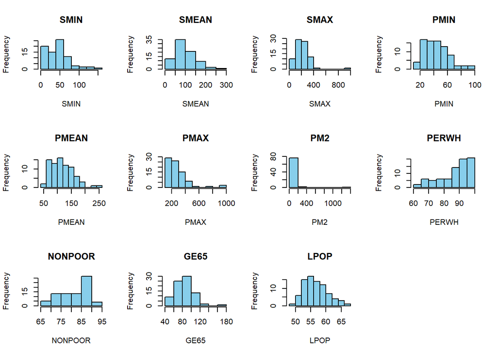

Figure 1 displays histograms for all variables in the air pollution dataset, created using the `hist()` function to explore their individual distributions. These histograms reveal key patterns in the data. For example, SMIN, SMEAN, and SMAX display right-skewed distributions, indicating that most cities have lower levels, but a few cities experience significantly higher concentrations. Similarly, PM2 shows a heavily right-skewed pattern, reflecting extreme particulate matter values in certain cities. On the other hand, demographic variables like PERWH and NONPOOR have more uniform or slightly left-skewed distributions, with most cities showing high percentages of white and non-poor populations. Interestingly, GE65 (percentage of population aged 65+) and LPOP (log population) demonstrate relatively symmetric distributions. These visualisations provide a comprehensive overview of variability and skewness, offering insights into both environmental and demographic diversity in the dataset, which will be critical for interpreting our subsequent analyses.

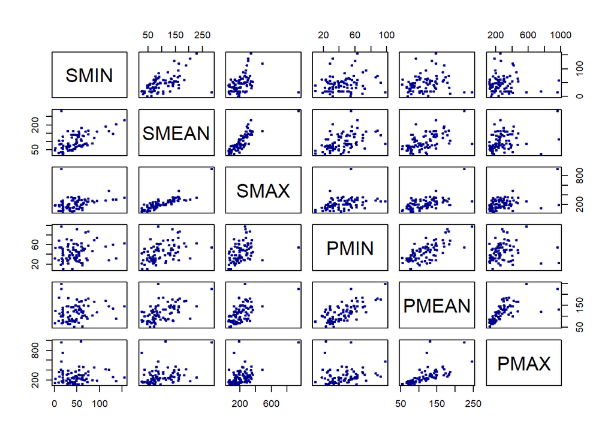

Subset of Air Pollution Variable

Figure 2 displays a scatterplot matrix focusing on sulphate concentrations (SMIN, SMEAN, SMAX) and particulate matter levels (PMIN, PMEAN, PMAX) to investigate relationships between these air pollution variables. The plots reveal strong positive correlations within each category of variables. For example, SMEAN and SMAX, representing average and maximum sulphate concentrations, show a clear linear relationship, suggesting that cities with higher average sulphate levels also experience higher peak values. Similarly, PMEAN and PMAX exhibit a similar pattern for particulate matter. However, the relationships between sulphate concentrations and particulate matter levels are weaker, indicating that while both measure pollution, they may be driven by different sources or environmental factors. This matrix provides a focused view of interactions within and between the key pollution metrics, enhancing our understanding of their distribution and correlation.

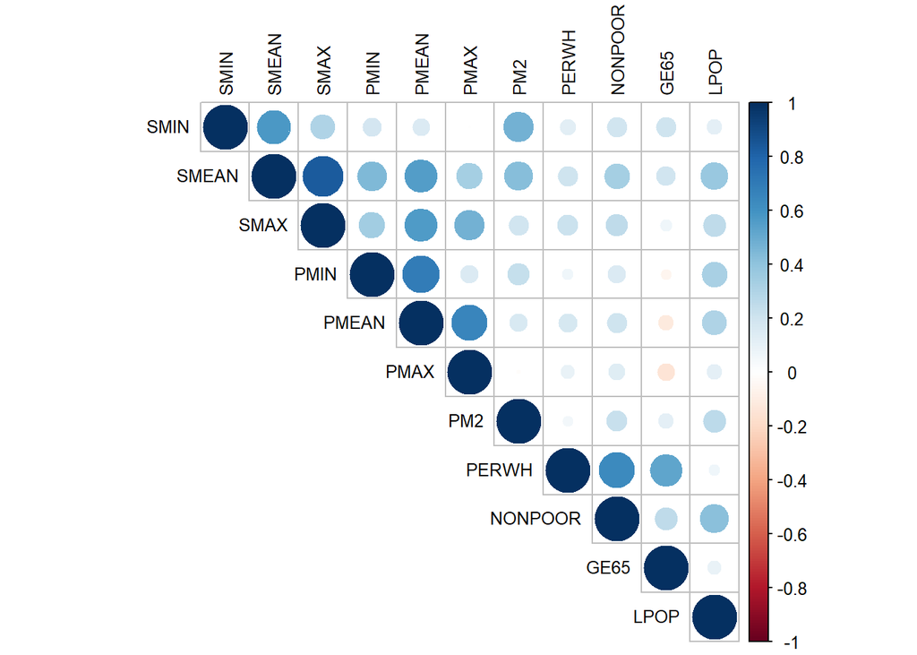

### 3. Statistical Computation and Standardisation

Table 3: Total Variation and Generalised Variance

| Metric | Value |
| --- | --- |
| Total Variation | 6.957797e+04 |
| Generalised Variance | 8.721310e+29 |

To compute the total variation and generalised variance of the dataset, we first calculated the covariance matrix using the `cov()` function. The total variation, derived as the sum of the diagonal elements of the covariance matrix using `sum(diag(cov_matrix))`, resulted in **69577.97**, reflecting the overall spread of the variables. Next, we computed the generalised variance using the determinant of the covariance matrix with `det(cov_matrix)`, which yielded **8.72131e+29**, indicating substantial multivariate variability. These calculations confirm the high variability present in the dataset, particularly among air pollution variables like PMAX and SMAX, which contribute significantly to the total spread.

#### 3.1 Mean Vector

Table 3: Mean Vector of Variance-Scaled Data

|  | Mean |
| --- | --- |
| SMIN | 0.8379184 |
| SMEAN | 0.8877965 |
| SMAX | 0.8734672 |
| PMIN | 0.9193029 |
| PMEAN | 0.9434948 |
| PMAX | 0.8619202 |
| PM2 | 0.4256757 |
| PERWH | 0.9868542 |
| NONPOOR | 0.9904164 |
| GE65 | 0.9641384 |
| LPOP | 0.9914587 |

#### 3.2 Covariance Matrix

Table 4: Covariance Matrix of Variance-Scaled Data

|  | SMIN | SMEAN | SMAX | PMIN | PMEAN | PMAX | PM2 | PERWH | NONPOOR | GE65 | LPOP |
| --- | --- | --- | --- | --- | --- | --- | --- | --- | --- | --- | --- |
| SMIN | 0.2890053 | 0.1386430 | 0.0775288 | 0.0368356 | 0.0262410 | -0.0004595 | 0.2299462 | 0.0080451 | 0.0085480 | 0.0262487 | 0.0042243 |
| SMEAN | 0.1386430 | 0.2018404 | 0.1782368 | 0.0764411 | 0.0780680 | 0.0757150 | 0.1708819 | 0.0109880 | 0.0121535 | 0.0208438 | 0.0114395 |
| SMAX | 0.0775288 | 0.1782368 | 0.2273976 | 0.0615930 | 0.0838966 | 0.1124433 | 0.0843355 | 0.0119877 | 0.0097356 | 0.0075436 | 0.0082374 |
| PMIN | 0.0368356 | 0.0764411 | 0.0615930 | 0.1441845 | 0.0828578 | 0.0301522 | 0.0822123 | 0.0026869 | 0.0048430 | -0.0048267 | 0.0082793 |
| PMEAN | 0.0262410 | 0.0780680 | 0.0838966 | 0.0828578 | 0.0985495 | 0.1025774 | 0.0463752 | 0.0065971 | 0.0052158 | -0.0086440 | 0.0064390 |
| PMAX | -0.0004595 | 0.0757150 | 0.1124433 | 0.0301522 | 0.1025774 | 0.2476896 | -0.0045136 | 0.0057963 | 0.0054300 | -0.0177365 | 0.0039825 |
| PM2 | 0.2299462 | 0.1708819 | 0.0843355 | 0.0822123 | 0.0463752 | -0.0045136 | 0.8165066 | 0.0060802 | 0.0162982 | 0.0251285 | 0.0161608 |
| PERWH | 0.0080451 | 0.0109880 | 0.0119877 | 0.0026869 | 0.0065971 | 0.0057963 | 0.0060802 | 0.0137912 | 0.0061049 | 0.0150240 | 0.0005046 |
| NONPOOR | 0.0085480 | 0.0121535 | 0.0097356 | 0.0048430 | 0.0052158 | 0.0054300 | 0.0162982 | 0.0061049 | 0.0066586 | 0.0050532 | 0.0023002 |
| GE65 | 0.0262487 | 0.0208438 | 0.0075436 | -0.0048267 | -0.0086440 | -0.0177365 | 0.0251285 | 0.0150240 | 0.0050532 | 0.0586706 | 0.0015602 |
| LPOP | 0.0042243 | 0.0114395 | 0.0082374 | 0.0082793 | 0.0064390 | 0.0039825 | 0.0161608 | 0.0005046 | 0.0023002 | 0.0015602 | 0.0045666 |